# Apportionment: How a Count Becomes Seats

Equal proportions, the seats the 2020 census moved, and a margin smaller than the instrument

Democracy’s Data

Last updated September 13, 2026 at 10:53a EDT

Political power in America is supposed to follow the census. Article I, Section 2 orders a count every ten years, and orders that House seats be apportioned — divided up in proportion — among the states “according to their respective Numbers.”[^1] Every civics course states it as a fact. What the clause does not say is *how*: dividing 435 seats among 50 states essentially never comes out in whole numbers, and whichever way the fractions are settled will benefit one state at another’s cost. So the question here is the how. By what rule does a count become seats, and how finely can that rule cut?

The 2020 answer ends at a very sharp edge. The last of the 435 seats went to Minnesota. The state next in line was New York, and the distance between them was 89 people, a large lecture hall. Because the count fell that way, New York casts one fewer vote on every bill that passes the House for a decade. It casts one fewer vote for President in two elections, since a state’s electors are its seats plus two.[^2]

That margin is the number everyone quotes about the 2020 census, almost always to argue that the count needed to be more accurate. Whether the margin can bear that argument is where this brief ends, and the answer is not the obvious one.

## The test

The question is answered from the Bureau’s own record of the hand-out: the *2020 Census Apportionment Results*, published in April 2021 at https://www.census.gov/data/tables/2020/dec/2020-apportionment-data.html. Table 1 carries each state’s apportionment population, its seats, and its change from 2010. Table 3 carries the population counted overseas. A third table, *Priority Values*, publishes the arithmetic itself: every House seat from 51 to 445, the state that took it, and the value it was won at.

No other source could serve. The seats in this file are not a measurement of how many seats the states have. They **are** how many seats the states have, reported by the agency that ran the count under a legal deadline. And because the Bureau publishes the queue as well as the result, the rule can be re-run here and checked against the publisher to the last digit. Very little political data can be audited that completely.

The count underneath the file is the decennial census. The decennial census chapter is that data’s biography: what the count asks, who is in it, and who it fails to find. This brief takes the count as given and follows what the law does with it. The rule in force is the **method of equal proportions**, also called Huntington–Hill. Congress changed methods five times before fixing this one by statute in 1941,[^3] and the size of the House, 435, has been a statute of its own since 1929.

## The data

The Bureau publishes those three tables as spreadsheets. The three tables here are their state rows, with the title and total rows removed.

`apportionment_2020.csv` has one row per state and five columns besides the name: `resident_pop`, `overseas`, `app_pop`, `seats`, and `people_per_seat`. Fifty rows, not fifty-one: the District of Columbia has no apportioned Representative and does not appear. Here is one row.

| State | People living there | Counted from abroad | Apportionment population | Seats |
| --- | --- | --- | --- | --- |
| California | 39,538,223 | 38,534 | 39,576,757 | 52 |

Read the middle columns slowly, because **the apportionment population is not the population of the state**. Federal employees serving abroad, mostly military, are counted and assigned back to a home state, and `app_pop` is `resident_pop` plus that `overseas` column. The assignment is a rule written in advance, not a measurement, and it could defensibly have been written another way. Nationally it moves 348,698 people, and this brief returns to what that does.

`priority_values.csv` is the Bureau’s published queue: one row per House seat from 51 onward, with `house_seat`, `state`, `state_seat` (which of that state’s own seats it was), and `priority`, the value it was won at. The table runs ten seats past the 435 the statute allows, which turns out to matter.

`seat_change_states.csv` carries `seats_2010`, `seats_2020`, and `change` for every state, from Table 1’s own comparison column.

> **Before the findings, write down two numbers.** First: out of 435 seats, how many do you think changed states after the 2020 count? Second: New York missed the last seat by 89 people — how far short do you think the *next* state in line was? Hundreds, thousands, hundreds of thousands? Written down, not thought about: the end of this brief is a comparison against your two guesses.

## What it says about democracy

The rule is short enough to write out in full. Every state starts with the one seat the Constitution guarantees it. The remaining 385 are handed out one at a time, and before each hand-out every state posts a bid, called its **priority value**. For a state’s $k$th seat the bid is

$$\text{priority} \;=\; \frac{\text{population}}{\sqrt{k(k-1)}}$$

and the highest bid takes the seat. That is the whole method. The divisor grows with every seat a state wins, so winning lowers your own next bid, and that is the entire reason the queue self-corrects instead of handing the whole House to California.

Follow the first three seats by hand. When seat 51 is handed out, every state holds exactly one seat, so every state is bidding for its second: $k = 2$, and the divisor is $\sqrt{2 \times 1}$ = 1.41421 for all of them. California, with 39,576,757 people, bids 39,576,757 ÷ 1.41421 = 27,984,993. Texas, with 29,183,290 people, bids 20,635,702. Nobody can beat California, so seat 51 is California’s second. Winning changes California’s next bid and nobody else’s: it is now asking for its third seat, $k = 3$, the divisor is $\sqrt{3 \times 2}$ = 2.44949, and its bid falls to 39,576,757 ÷ 2.44949 = 16,157,143. Texas’s 20,635,702 is now the highest bid on the table, so seat 52 is Texas’s second. That drops Texas to 11,914,028, which puts California’s 16,157,143 back on top, ahead of Florida’s 15,252,666, and seat 53 is California’s third. The queue runs like that 385 times.[^4] Here are its first twelve steps, with the arithmetic spelled out.

| House seat | Goes to | That state’s | Population | Divisor | Priority |
| --- | --- | --- | --- | --- | --- |
| 51 | California | 2nd seat | 39,576,757 | 1.41421 | 27,984,993 |
| 52 | Texas | 2nd seat | 29,183,290 | 1.41421 | 20,635,702 |
| 53 | California | 3rd seat | 39,576,757 | 2.44949 | 16,157,143 |
| 54 | Florida | 2nd seat | 21,570,527 | 1.41421 | 15,252,666 |
| 55 | New York | 2nd seat | 20,215,751 | 1.41421 | 14,294,695 |
| 56 | Texas | 3rd seat | 29,183,290 | 2.44949 | 11,914,028 |
| 57 | California | 4th seat | 39,576,757 | 3.46410 | 11,424,826 |
| 58 | Pennsylvania | 2nd seat | 13,011,844 | 1.41421 | 9,200,763 |
| 59 | Illinois | 2nd seat | 12,822,739 | 1.41421 | 9,067,046 |
| 60 | California | 5th seat | 39,576,757 | 4.47214 | 8,849,632 |
| 61 | Florida | 3rd seat | 21,570,527 | 2.44949 | 8,806,131 |
| 62 | Texas | 4th seat | 29,183,290 | 3.46410 | 8,424,490 |

These are the Bureau’s own published priority values. Applying the formula to the population column reproduces every one of them to the last digit.

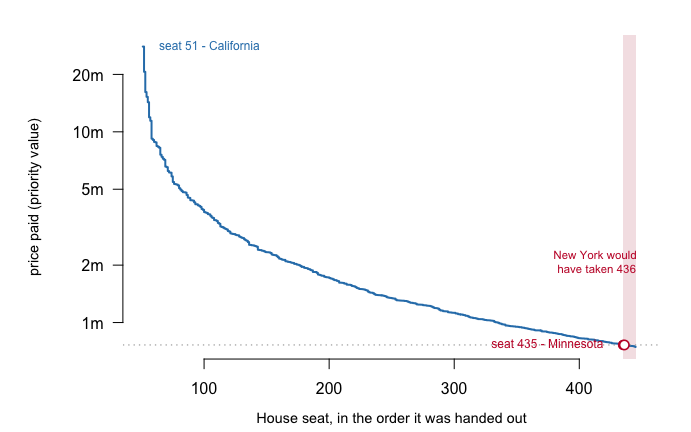

**Drag the slider** to replay the queue: the readout beneath shows the winning state’s arithmetic and the four highest bids at every step.

**Figure 1. The price of a seat, seat by seat, as the queue empties.** Each tread is one seat, drawn in the order it was won, at the priority value of the state that took it. A staircase fits the question because that is what the method is: the House handed out one seat at a time, at a price that only ever falls. Seat 51 went to California at 27,984,993; seat 435 went to Minnesota at 762,998, about 37-fold cheaper. In the browser, the slider replays the queue and shows the four highest bids at every step. The shaded band is the ten seats the Bureau tabulated past the statute; the open circle is the seat New York would have taken.

Run the queue from the population column alone and the claim can be tested directly.

| Check | Result |
| --- | --- |
| Seats handed out one at a time | 385 |
| Total when the queue empties | 435 |
| Does this reproduce the official House, state for state? | TRUE |
| Do the recomputed prices match the Bureau’s published ones? | TRUE |

**The recomputation reproduces the official House exactly, state for state.** There is no committee and no fudge factor. Once the census is counted, the House allocates itself.

### What the 2020 count moved

| State | Seats after 2010 | Seats after 2020 | Change |
| --- | --- | --- | --- |
| Texas | 36 | 38 | +2 |
| Colorado | 7 | 8 | +1 |
| Florida | 27 | 28 | +1 |
| Montana | 1 | 2 | +1 |
| North Carolina | 13 | 14 | +1 |
| Oregon | 5 | 6 | +1 |
| California | 53 | 52 | -1 |
| Illinois | 18 | 17 | -1 |
| Michigan | 14 | 13 | -1 |
| New York | 27 | 26 | -1 |
| Ohio | 16 | 15 | -1 |
| Pennsylvania | 18 | 17 | -1 |
| West Virginia | 3 | 2 | -1 |

**7 seats sit in different states than they did after 2010, across 13 states.** Texas took 2, 5 states took one each, and 7 states, New York among them, gave one up. No state moved by more than two. The direction is the country’s population story made political: the gains sit in the South and the West, the losses mostly in the Northeast and the industrial Midwest. And every one of those moves carries an elector with it, because a state’s Electoral College weight is its seats plus two.

### The last seat, and the queue behind it

The final seat is where the arithmetic gets finer than most people imagine a national count can be.

| Quantity | People |
| --- | --- |
| What New York was counted at | 20,215,751 |
| What New York needed to take that seat | 20,215,840 |
| Short by | 89 |

Had New York been counted 89 people higher, seat 435 would have been its 27th rather than Minnesota’s 8th. This is not a reconstruction: the Bureau kept computing past the statute, and its own table names the states that would have taken seats 436 through 440.

| If the House had this many seats | The next one would go to | Seat number | At a price of |
| --- | --- | --- | --- |
| 436 | New York | its 27th | 762,994 |
| 437 | Ohio | its 16th | 762,258 |
| 438 | Texas | its 39th | 758,071 |
| 439 | Florida | its 29th | 756,977 |
| 440 | Arizona | its 10th | 754,617 |

Now the second of your two guesses, answered for every state at once.

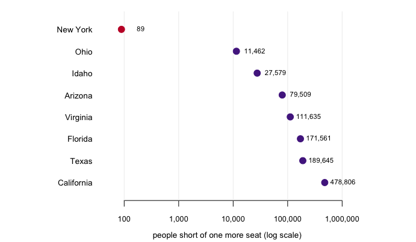

**Figure 2. How far every near-miss state was from one more seat.** The eight states closest to a further seat, ordered by how short they fell; each dot is the number of additional residents that state needed. The scale is logarithmic — each step along the axis multiplies by ten instead of adding a fixed amount, so that a few hundred and a million fit on one line — and the marks are dots rather than bars: bar length on a log axis would encode distance from an arbitrary origin rather than the quantity. New York is the red dot at 89. The next state, Ohio, is about 129 times further away.

Most readers guess that second place was also close — a few thousand, perhaps tens of thousands. It is 11,462. **New York’s near-miss was a freak event, and the distance to second place is the evidence.** Nothing about the 2020 apportionment was generally knife-edged; one comparison out of 50 happened to be.

Then a number nobody is asked to guess, because it sits inside New York’s own row.

| Quantity | People |
| --- | --- |
| New York’s population counted from overseas | 14,502 |
| Minnesota’s population counted from overseas | 3,258 |
| The margin that decided the 435th seat | 89 |

**New York had 14,502 people counted from abroad, about 163 times the margin.** A rule about where to assign soldiers stationed in Germany moved far more people than the count difference that settled the seat. Change that rule and you change the House, without changing a single person’s whereabouts.

So the obvious reading of the famous margin is wrong. 89 people is not evidence that the census needed to be counted more carefully. It is evidence that the margin fell below the resolution of the instrument: below the census’s own published uncertainty about state totals, and far below a policy choice already sitting inside the number. There is no recount for a census, and the quantity in dispute is 163 times smaller than an administrative rule inside the thing that would have to be recounted. **The near-miss is a fact about the rules, not about the accuracy of the count.**

## Activity: four states and a jar of pennies

If the near-miss is a fact about the rules, then the rules are the thing worth arguing with. Equal proportions is one of six methods Congress has used or considered, and they do not agree with one another.[^5] Fifty states are too many to argue about at once. Four are enough to produce the whole disagreement.

Put 19 people into four groups of 1, 2, 7, 9. Set 25 pennies on the table between them. Give one instruction: each group should end up with a share of the pennies matching its share of the people. Do not say how.

Every group can work out its own fair number in a minute, and every one of those numbers is defensible. The four numbers will not add up to 25. That is the problem the whole method fight is about, and it arrives before any formula does.

> **Write two numbers down before you touch the figure.** How many pennies should the group of 1 get, when its fair share is 1.32? And which group should give one up, so that the four numbers add to 25?

> **The six rules, without the arithmetic.** Every one of them is answering the same question: a group is owed a share with a fraction in it, and somebody has to decide what happens to the fraction.
> - **Adams** — round every share up. A sliver of a share still earns a whole penny, so the smallest group does best.
> - **Dean** — make each group’s people-per-penny as close to the average as it can be, measured in people.
> - **Huntington–Hill** — the same aim, measured in percentages instead of people. This is the one the United States has used since 1941.
> - **Webster** — ordinary rounding. Above the halfway point a share rounds up, below it rounds down.
> - **Jefferson** — round every share down. Fractions are simply discarded, which suits the group holding the most pennies already.
> - **Hamilton** — no rounding rule at all. Hand out the whole shares, then give the leftover pennies to whoever has the largest fractions.

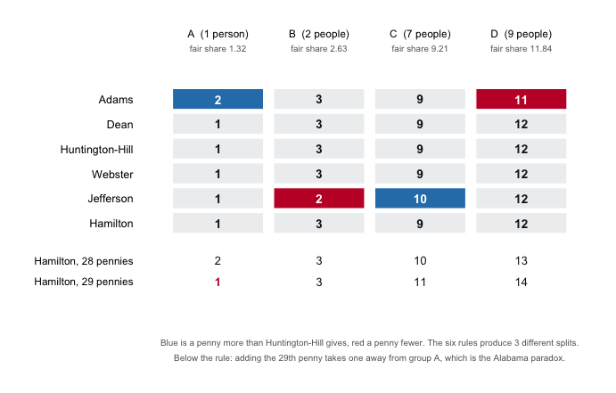

**Drag a group, then drag the pennies.** All six rules are re-run in the browser on every step; nothing is precomputed. The mandated first penny is on by default, which is what the Constitution does for the states, and at the opening numbers it changes nothing: every group clears one penny on its own. Turn it off and set three groups to 1 against a fourth at 9, with 8 pennies, to see what it is for.

**Figure 3. Six rules, four groups, 25 pennies.** Each row is one of the six rules listed above, run over four group sizes instead of fifty state populations. Cells in bold differ from Huntington–Hill, the method in force since 1941: blue is a penny more, red a penny fewer. In the browser the sliders set the four group sizes and the number of pennies. The checkbox decides whether every group is handed one penny before the rules start. All six rules are re-run on every step.

Six rules produce 3 different answers here. Adams’s method gives the smallest group 2 pennies and takes one off the largest. Jefferson’s gives the group of 2 one fewer and hands it to the group of 7. Hamilton’s method agrees with Huntington–Hill at this setting, which it will not do once you start moving the pennies. Nobody has miscounted anything. The group sizes are known exactly, and every bit of the disagreement is about the remainder.

A room full of people makes the same point faster. The largest group reliably invents something close to rounding down, which is Jefferson’s method. The smallest reliably insists that it cannot be left with nothing, which is Huntington–Hill’s guaranteed seat. Both are arguing their own interest, and both are quoting a rule the United States has actually used. Jefferson was Virginia, the largest state in the union. Webster and John Quincy Adams were New England, and New England was small.[^6]

Four things to do with it, in the version with the sliders:

- **Make the House bigger and watch a group get smaller.** Press *set up the paradox*, which puts 28 pennies on the table, then move the pennies one step to 29. Group A drops from 2 to 1 under Hamilton’s method. There is more to hand out and one group receives less. That is the **Alabama paradox**, named for the 1880 census, when the House found that growing from 299 seats to 300 would take a seat away from Alabama.[^7] The last two rows of the printed figure carry the same two lines.
- **Make the same move under the other five rules.** Nothing falls. A divisor method runs a queue like the one this brief opened with, and lengthening a queue cannot take back what it has already handed out.
- **Set all four groups to the same size.** Every rule ends up starred, because the last penny is a genuine tie and the answer turns on a coin flip. The exercise is dead at that setting, which is why the numbers it opens on were searched for rather than picked.
- **Turn off the mandated first penny.** Set three groups to 1 against a fourth at 9, with 8 pennies. Jefferson’s method gives the large group all eight and the other three nothing. That is what the constitutional floor is for, and it is a floor rather than a property of the rule, because three of these six rules would not impose it on their own.

None of this is a simplified version of the real thing. It is the real thing, with the populations small enough to hold in your head. The rules are the same rules and the failures are the same failures. The reason there is no neutral answer for four groups is the reason there is none for fifty states.

## What this brief cannot tell you

The file has authority without uncertainty. Every population is printed as an exact whole number, and none is exact. The Bureau publishes its coverage error separately, on a different schedule — the coverage brief reads it — and puts state-level error in the hundreds of thousands, far above 89. So this brief cannot say that a more careful count would have moved the seat. Nothing here measures enumeration error, and no second source exists against which to check the first.

It is one decade. Whether *some* state is always within a few thousand people of a seat cannot be settled from a single census; that would take the 1990, 2000, and 2010 files alongside.

It says nothing about districts. Apportionment decides how many seats a state gets; districting decides where the lines go inside it, and the two are confused constantly.

And it cannot judge the rule itself. Congress chose equal proportions over five rivals that are equally defensible and do not agree, and the Supreme Court, in *Department of Commerce v. Montana* (1992), declined to second-guess the choice.[^8] Which method is fairest is a value judgment wearing technical clothes, and no column in this file settles it.

## What you should have learned

- A formula short enough to write in one line — population over $\sqrt{k(k-1)}$, highest bid wins — turns the count into the House, and recomputing it here reproduces the Bureau’s published seats and prices exactly.
- The 2020 count moved 7 seats across 13 states, and each seat moved an Electoral College vote with it.
- New York missed the final seat by 89 people, while the next state in line was 11,462 short: the near-miss was an outlier, not the normal state of affairs.
- The margin was smaller than the instrument. New York’s own total includes 14,502 people assigned to it by a rule about federal employees abroad, roughly 163 times the margin that decided the seat.
- The rule is a choice, and the choices disagree. Over four groups and 25 pennies, the six methods Congress has used or considered produce 3 different answers, with every group size known exactly and nothing miscounted.

## Extensions

- `apportionment_2020.csv` — sort by `overseas`. Which states gain the most from people counted abroad, and how do those counts compare with the 89-person margin?
- `apportionment_2020.csv` — find the largest and smallest `people_per_seat`. How many times over is one person’s share of the House worth another’s, and are the two extreme states large or small?
- `priority_values.csv` — filter `house_seat` to 430 through 445 and watch the queue cross the statute. How many different states appear in those sixteen rows?
- `seat_change_states.csv` — sort by `change`, then by `seats_2020`. Do the states that lost seats tend to be larger or smaller than the states that gained them?
- **Stretch.** The Bureau publishes the same tables for 2010, 2000, and 1990 on the same page. Download one and find that decade’s last seat and nearest miss: is a two-digit margin usual, or was 2020 unique?
- **Stretch.** Webster’s method uses the divisor $k + 0.5$ instead of $\sqrt{k(k-1)}$. Re-run the queue in a spreadsheet with that one change and see which, if any, of the 435 seats move.

## Sources

**Data**

- U.S. Census Bureau, *2020 Census Apportionment Results*, Table 1 (apportionment population and seats, with change from 2010) and Table 3 (population counted overseas), and *Priority Values for 2020 Census Apportionment*, which lists every seat from 51 to 445 with the value it was won at. https://www.census.gov/data/tables/2020/dec/2020-apportionment-data.html

**The data itself**

Every figure above is drawn from these tables. They are plain CSV, they open in a spreadsheet, and they are yours to take further.

`apportionment_2020.csv`, `priority_values.csv`, `seat_change_labels.csv`, `seat_change_rings.csv`, `seat_change_states.csv`, `state_rings.csv`

**Literature**

- Balinski, M. L. and Young, H. P. (2001). *Fair Representation: Meeting the Ideal of One Man, One Vote*, 2nd edn. Washington, D.C.: Brookings Institution Press. ISBN 978-0-8157-0111-8. The six methods, the impossibility result and the history of the fights over which rule to use are worked out here. https://www.brookings.edu/books/fair-representation/

**Statutes and cases**

- U.S. Const. art. I, § 2, cl. 3; amend. XIV, § 2. https://www.archives.gov/founding-docs/constitution-transcript
- Permanent Apportionment Act of 1929, 46 Stat. 21; method of equal proportions fixed by Act of 15 November 1941, 55 Stat. 761 (now 2 U.S.C. §2a). https://www.law.cornell.edu/uscode/text/2/2a
- *Department of Commerce v. Montana*, 503 U.S. 442 (1992). https://www.law.cornell.edu/supremecourt/text/503/442

Rebuild this data yourself, with an AI assistant

```
I want to rebuild a public dataset from its original source, without any
starting files. Please do the following and show your work.

THE SOURCE. U.S. Census Bureau, 2020 Census apportionment results --
the count that decides how many House seats each state gets. The
tables are linked from
https://www.census.gov/data/tables/2020/dec/2020-apportionment-data.html
and served plainly from
https://www2.census.gov/programs-surveys/decennial/2020/data/apportionment/
as apportionment-2020-table01.xlsx, apportionment-2020-table03.xlsx and
2020PriorityValues.xlsx, a few kilobytes each. No account or key is
needed. Table 1 is one row per state: its apportionment population, the
seats it received, and the change from 2010. Table 3 is the overseas
population -- federal employees serving abroad and their dependents,
counted back into a home state -- which is the difference between the
apportionment population and the resident population. The priority
values workbook is the arithmetic itself: one row per House seat, the
state that took it, which of that state's own seats it was, and the
priority value it was won at. Each workbook carries a few title rows
above the data, and the first two carry a footnoted TOTAL row; keep the
state rows.

WHAT TO BUILD.
1. A fifty-state table: apportionment population, seats, seat change
   from 2010, and the overseas count folded into each state's total.
2. People per seat, state by state: divide each state's apportionment
   population by its seats, and look at how wide the spread is.
3. The published priority queue as a table, and then the same queue
   recomputed from the population column alone. For a state's kth seat
   the priority value is its population divided by the square root of
   k times k-1. Assign every state one seat, then hand out the rest one
   at a time to whichever state has the highest priority value.

CHECK YOUR WORK. The copies this book used were downloaded in August
2026. If your rebuild matches them, you should find:
- 50 states -- no District of Columbia, no Puerto Rico -- whose seats
  sum to 435
- California is largest: 39,576,757 people and 52 seats, which works
  out to 761,091 people per seat
- California's overseas count is 38,534
- the priority table starts at House seat 51 and runs to House seat
  445, ten past the 435 the statute allows
- your recomputed priority values match the published ones, and the
  seats they produce match the published seat column state for state
These tables are a finished record of the 2020 census. Nothing in
them will change until the 2030 census produces a new set.
```

[^1]: U.S. Const. art. I, § 2, cl. 3, text at the National Archives: https://www.archives.gov/founding-docs/constitution-transcript.
[^2]: U.S. Const. art. II, § 1, cl. 2: each state appoints electors equal to its Senators and Representatives together. https://www.law.cornell.edu/constitution/articleii.
[^3]: The Census Bureau’s own history of the methods, from Jefferson’s to equal proportions: https://www.census.gov/topics/public-sector/congressional-apportionment/about/historical-perspective.html. The 1941 act is now 2 U.S.C. § 2a: https://www.law.cornell.edu/uscode/text/2/2a.
[^4]: The Bureau walks through the same arithmetic on its page “Computing Apportionment”: https://www.census.gov/topics/public-sector/congressional-apportionment/about/computing.html.
[^5]: Michel L. Balinski and H. Peyton Young, *Fair Representation: Meeting the Ideal of One Man, One Vote*, 2nd ed. (Washington, D.C.: Brookings Institution Press, 2001), https://www.brookings.edu/books/fair-representation/.
[^6]: Balinski and Young, *Fair Representation*, trace who sponsored each method and which states it favoured.
[^7]: The Census Bureau’s account of the episode: https://www.census.gov/topics/public-sector/congressional-apportionment/about/historical-perspective.html.
[^8]: 503 U.S. 442 (1992): https://www.law.cornell.edu/supremecourt/text/503/442.